# Tibbles, with solutions (ds4psy)

**Hint:** The plots are created with `geom_step` and `geom_area`. However, rather than directly calling `ggplot`, consider first using `dplyr` to transform `dec_1` into summary tables that contain all values needed for the plots. You may have to combine multiple `group_by` and `mutate` commands to compute all required variables.

Purchases by day and name (with cum sum by name).

| day | name | n | sm_pay | cum_sum |
| --- | --- | --- | --- | --- |
| Mon | Anna | 2 | 4.50 | 4.50 |
| Mon | Brian | 1 | 3.80 | 3.80 |
| Mon | Caro | 1 | 6.30 | 6.30 |
| Tue | Anna | 1 | 4.50 | 9.00 |
| Tue | Brian | 1 | 11.80 | 15.60 |
| Tue | Caro | 1 | 6.10 | 12.40 |
| Wed | Anna | 2 | 7.15 | 16.15 |
| Wed | Brian | 1 | 16.20 | 31.80 |
| Thu | Anna | 1 | 4.80 | 20.95 |
| Thu | Caro | 1 | 2.90 | 15.30 |
| Fri | Brian | 1 | 4.50 | 36.30 |
| Fri | Caro | 1 | 3.20 | 18.50 |
| Sat | Anna | 1 | 4.40 | 25.35 |
| Sat | Caro | 1 | 9.95 | 28.45 |
| Sun | Anna | 1 | 12.50 | 37.85 |
| Sun | Brian | 1 | 8.80 | 45.10 |

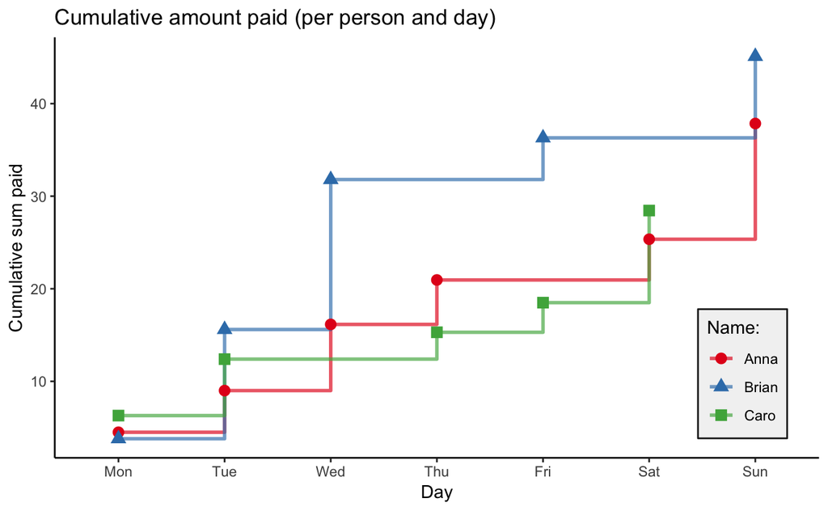

```
#> # A tibble: 18 x 4
#>    name  day   what          paid
#>    <chr> <ord> <chr>        <dbl>
#>  1 Anna  Mon   Bread         2.5
#>  2 Anna  Mon   Butter        2
#>  3 Anna  Tue   Pasta         4.5
#>  4 Anna  Wed   Pencils       3.25
#>  5 Anna  Wed   Cream         3.9
#>  6 Anna  Thu   Milk          4.8
#>  7 Anna  Sat   Cookies       4.4
#>  8 Anna  Sun   Cake         12.5
#>  9 Brian Mon   Chips         3.8
#> 10 Brian Tue   Beer         11.8
#> 11 Brian Wed   Steak        16.2
#> 12 Brian Fri   Toilet paper  4.5
#> 13 Brian Sun   Wine          8.8
#> 14 Caro  Mon   Fruit         6.3
#> 15 Caro  Tue   Batteries     6.1
#> 16 Caro  Thu   Newspaper     2.9
#> 17 Caro  Fri   Honey         3.2
#> 18 Caro  Sat   Detergent     9.95
```

Cumulative sums (by day and name).

| day | name | n | sum_name_day | cum_sum_name | cum_sum_day | pc_name |
| --- | --- | --- | --- | --- | --- | --- |
| Mon | Anna | 2 | 4.50 | 4.50 | 14.60 | 30.82192 |
| Mon | Brian | 1 | 3.80 | 3.80 | 14.60 | 26.02740 |
| Mon | Caro | 1 | 6.30 | 6.30 | 14.60 | 43.15068 |
| Tue | Anna | 1 | 4.50 | 9.00 | 37.00 | 24.32432 |
| Tue | Brian | 1 | 11.80 | 15.60 | 37.00 | 42.16216 |
| Tue | Caro | 1 | 6.10 | 12.40 | 37.00 | 33.51351 |
| Wed | Anna | 2 | 7.15 | 16.15 | 60.35 | 26.76056 |
| Wed | Brian | 1 | 16.20 | 31.80 | 60.35 | 52.69263 |
| Wed | Caro | 1 | 0.00 | 12.40 | 60.35 | 20.54681 |
| Thu | Anna | 1 | 4.80 | 20.95 | 68.05 | 30.78619 |
| Thu | Brian | 1 | 0.00 | 31.80 | 68.05 | 46.73035 |
| Thu | Caro | 1 | 2.90 | 15.30 | 68.05 | 22.48347 |
| Fri | Anna | 1 | 0.00 | 20.95 | 75.75 | 27.65677 |
| Fri | Brian | 1 | 4.50 | 36.30 | 75.75 | 47.92079 |
| Fri | Caro | 1 | 3.20 | 18.50 | 75.75 | 24.42244 |
| Sat | Anna | 1 | 4.40 | 25.35 | 90.10 | 28.13541 |
| Sat | Brian | 1 | 0.00 | 36.30 | 90.10 | 40.28857 |
| Sat | Caro | 1 | 9.95 | 28.45 | 90.10 | 31.57603 |
| Sun | Anna | 1 | 12.50 | 37.85 | 111.40 | 33.97666 |
| Sun | Brian | 1 | 8.80 | 45.10 | 111.40 | 40.48474 |
| Sun | Caro | 1 | 0.00 | 28.45 | 111.40 | 25.53860 |

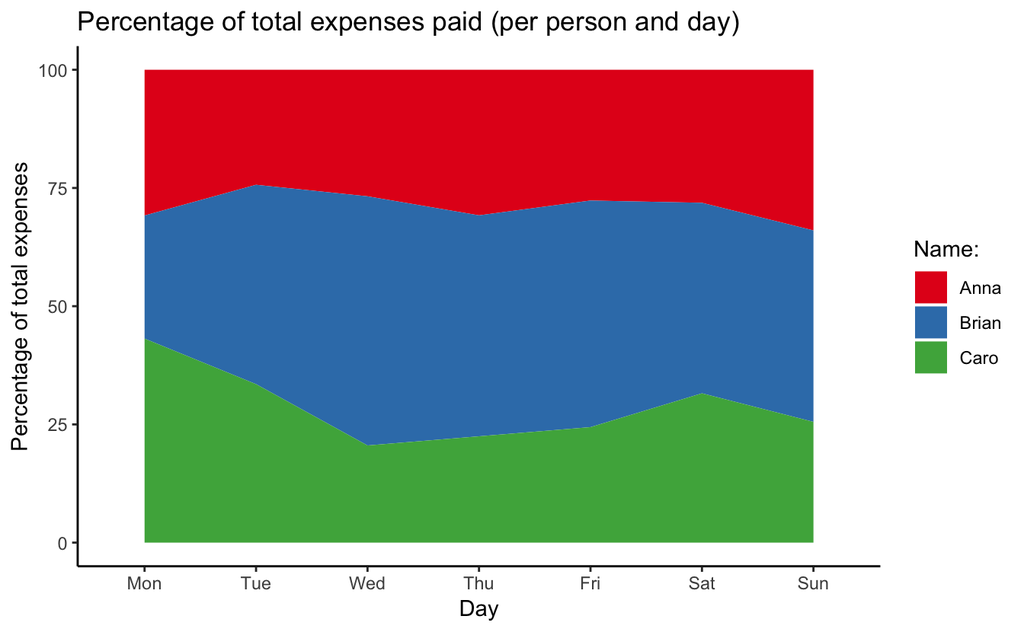

**Note:** An alternative way to represent the purchases would as a list (an R data structure that – in contrast to vectors – allows a mix of different data types):

```r
# A more natural format (to represent a purchase) would have been:

buy  <- list("Anna", "Mon", "Bread", 2.50)  # by purchase

# but as column vectors don't allow mixing data types (e.g., characters and numbers),
# we represented the purchases as the rows of a table/tibble above.
```

## Exercise 3

#### Positive psychology tibbles

In this exercise, we will enter some results from our previous session (on [Exploring data (EDA)](http://rpository.com/ds4psy/essentials/explore.html)) as a tibble, before re-computing the results from the raw data and visualizing the results.

To do this exercise, re-load the following data files (into R objects `posPsy_wide` and `posPsy_long`):

```r
# Load data:
posPsy_wide <- read_csv(file = "http://rpository.com/ds4psy/data/posPsy_data_wide.csv")
dim(posPsy_wide)  # 295 294
```

```
#> [1] 295 294
```

```r
# 3. Corrected DVs in long format:
posPsy_long <- read_csv(file = "http://rpository.com/ds4psy/data/posPsy_AHI_CESD_corrected.csv")
dim(posPsy_long)  # 990 x 50
```

```
#> [1] 990  50
```

Table: Mean depression scores by intervention and occasion.

| intervention | mn_cesd_0 | mn_cesd_1 | mn_cesd_2 | mn_cesd_3 | mn_cesd_4 | mn_cesd_5 |
| --- | --- | --- | --- | --- | --- | --- |
| 1 | 15.1 | 15.3 | 13.6 | 12.0 | 11.2 | 13.5 |
| 2 | 16.2 | 14.6 | 11.4 | 12.5 | 13.4 | 14.6 |
| 3 | 16.1 | 12.3 | 14.8 | 13.9 | 14.9 | 13.0 |
| 4 | 12.8 | 9.9 | 9.5 | 9.1 | 7.7 | 10.2 |

1. Enter this data directly into a tibble `my_tbl` (by using either the `tibble` or the `tribble` command).

```r
# (1a): Create the tibble displayed above.
my_tbl <- tibble(intervention = c(1:4),
                 mn_cesd_0 = c(15.1, 16.2, 16.1, 12.8),
                 mn_cesd_1 = c(15.3, 14.6, 12.3, 9.9),
                 mn_cesd_2 = c(13.6, 11.4, 14.8, 9.5),
                 mn_cesd_3 = c(12.0, 12.5, 13.9, 9.1),
                 mn_cesd_4 = c(11.2, 13.4, 14.9, 7.7),
                 mn_cesd_5 = c(13.5, 14.6, 13.0, 10.2) )

my_tbl
```

```
#> # A tibble: 4 x 7
#>   intervention mn_cesd_0 mn_cesd_1 mn_cesd_2 mn_cesd_3 mn_cesd_4 mn_cesd_5
#>          <int>     <dbl>     <dbl>     <dbl>     <dbl>     <dbl>     <dbl>
#> 1            1      15.1      15.3      13.6      12        11.2      13.5
#> 2            2      16.2      14.6      11.4      12.5      13.4      14.6
#> 3            3      16.1      12.3      14.8      13.9      14.9      13
#> 4            4      12.8       9.9       9.5       9.1       7.7      10.2
```

2. Re-compute an identical tibble `my_tbl_2` by transforming one of the `posPsy_...` datasets (using `dplyr`) and verify that `my_tbl` and `my_tbl_2` are equal.

```r
my_tbl_2 <- posPsy_wide %>%
  group_by(intervention) %>%
  summarise(mn_cesd_0 = round(mean(cesdTotal.0, na.rm = TRUE), 1),
            mn_cesd_1 = round(mean(cesdTotal.1, na.rm = TRUE), 1),
            mn_cesd_2 = round(mean(cesdTotal.2, na.rm = TRUE), 1),
            mn_cesd_3 = round(mean(cesdTotal.3, na.rm = TRUE), 1),
            mn_cesd_4 = round(mean(cesdTotal.4, na.rm = TRUE), 1),
            mn_cesd_5 = round(mean(cesdTotal.5, na.rm = TRUE), 1) )

# my_tbl_2

# Verify that they are equal:
all.equal(my_tbl, my_tbl_2)  # TRUE
```

```
#> [1] TRUE
```

3. Visualize the information expressed by `my_tbl` in a transparent way (e.g., by creating a bar or line plot).

**Hint:** If this is difficult by using `data = my_tbl` in `ggplot`, use a data file that is better suited for this purpose. *Why* can’t you just directly plot `my_tbl`?

```r
# Problem:
# my_tbl contains the results, but distributed over 6 different variables.
# To plot this data, we would need a format with only 1 dependent variable.

# Using the data from posPsy_long
# (in which cesdTotal is only 1 variable, which we can group by occasion and intervention):
my_tbl_3 <- posPsy_long %>%
  group_by(occasion, intervention) %>%
  summarize(mean_cesd = round(mean(cesdTotal), 1))
# my_tbl_3

# Turn intervention into a factor:
my_tbl_3$intervention <- factor(my_tbl_3$intervention)
# my_tbl_3

# Note the difference:
knitr::kable(my_tbl_3, caption = "Table: This table contains our key dependent variable (mean_cesd) in 1 column.")
```

Table: This table contains our key dependent variable (mean_cesd) in 1 column.

| occasion | intervention | mean_cesd |
| --- | --- | --- |
| 0 | 1 | 15.1 |
| 0 | 2 | 16.2 |
| 0 | 3 | 16.1 |
| 0 | 4 | 12.8 |
| 1 | 1 | 15.3 |
| 1 | 2 | 14.6 |
| 1 | 3 | 12.3 |
| 1 | 4 | 9.9 |
| 2 | 1 | 13.6 |
| 2 | 2 | 11.4 |
| 2 | 3 | 14.8 |
| 2 | 4 | 9.5 |
| 3 | 1 | 12.0 |
| 3 | 2 | 12.5 |
| 3 | 3 | 13.9 |
| 3 | 4 | 9.1 |
| 4 | 1 | 11.2 |
| 4 | 2 | 13.4 |
| 4 | 3 | 14.9 |
| 4 | 4 | 7.7 |
| 5 | 1 | 13.5 |
| 5 | 2 | 14.6 |
| 5 | 3 | 13.0 |
| 5 | 4 | 10.2 |

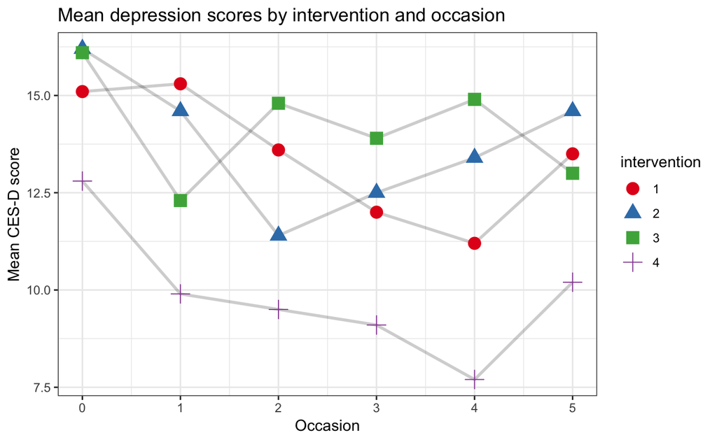

```r
# Visualize summary table as line graph:
ggplot(my_tbl_3, aes(x = occasion, y = mean_cesd, group = intervention,
                     color = intervention, shape = intervention)) +
  geom_line(size = 1, color = "black", alpha = .20) +
  geom_point(size = 4) +
  labs(title = "Mean depression scores by intervention and occasion",
       x = "Occasion", y = "Mean CES-D score") +
  scale_color_brewer(palette = "Set1") +
  theme_bw()
```

## Exercise 4

#### False-positive psychology

Having considered the benefits of positive psychology, we can now consider the pitfalls of false-positive psychology. The following article reports noteworthy results based on 2 datasets:

- Simmons, J.P., Nelson, L.D., & Simonsohn, U. (2011). False-positive psychology: Undisclosed flexibility in data collection and analysis allows presenting anything as significant. *Psychological Science*, *22*(11), 1359–1366. doi: https://doi.org/10.1177/0956797611417632

You can find background information on this article and its data at [Datasets: False positive psychology](http://rpository.com/ds4psy/essentials/datasets.html#false-positive-psychology).

The following table was created from the data of both studies. It reports the mean, minimum, and maximum age of participants per condition `cond`, as well as the number of people in those conditions who reported to feel a certain age (from very young to very old):

Table: Age-related data from Simmons et al. (2011).

| cond | n | mean_age | youngest | oldest | feel_vyoung | feel_young | feel_neither | feel_old | feel_vold |
| --- | --- | --- | --- | --- | --- | --- | --- | --- | --- |
| 64 | 25 | 21.09 | 18.30 | 38.24 | 0 | 13 | 10 | 2 | 0 |
| control | 22 | 20.80 | 18.53 | 27.23 | 3 | 15 | 3 | 1 | 0 |
| potato | 31 | 20.60 | 18.18 | 27.37 | 1 | 17 | 11 | 2 | 0 |

1. Enter this data as a tibble `tbl_1` (by using the `tibble` or the `tribble` command).

```r
# (a) Using tibble:
tbl_1 <- tibble(
  cond = c("64", "control", "potato"),
  n = c(25, 22, 31),
  mean_age = c(21.09, 20.80, 20.60),
  youngest = c(18.30, 18.53, 18.18),
  oldest = c(38.24, 27.23, 27.37),
  feel_vyoung = c(0, 3, 1),
  feel_young = c(13, 15, 17),
  feel_neither = c(10, 3, 11),
  feel_old = c(2, 1, 2),
  feel_vold = c(0, 0, 0) )

knitr::kable(tbl_1, caption = "Data entered (by using tibble).")
```

Data entered (by using tibble).

| cond | n | mean_age | youngest | oldest | feel_vyoung | feel_young | feel_neither | feel_old | feel_vold |
| --- | --- | --- | --- | --- | --- | --- | --- | --- | --- |
| 64 | 25 | 21.09 | 18.30 | 38.24 | 0 | 13 | 10 | 2 | 0 |
| control | 22 | 20.80 | 18.53 | 27.23 | 3 | 15 | 3 | 1 | 0 |
| potato | 31 | 20.60 | 18.18 | 27.37 | 1 | 17 | 11 | 2 | 0 |

```r
# (b) Using tribble:
tbl_2 <- tribble(~cond, ~n, ~mean_age, ~youngest, ~oldest,
                 ~feel_vyoung, ~feel_young, ~feel_neither, ~feel_old,   ~feel_vold,
                 #--------|----|------|------|------|---|---|---|---|---|
                 "64",      25, 21.09, 18.30,   38.24,  0, 13, 10,  2,  0,
                 "control", 22, 20.80, 18.53,   27.23,  3, 15,  3,  1,  0,
                 "potato",  31, 20.60, 18.18,   27.37,  1, 17, 11,  2,  0 )

knitr::kable(tbl_2, caption = "Data entered (by using tribble).")
```

Data entered (by using tribble).

| cond | n | mean_age | youngest | oldest | feel_vyoung | feel_young | feel_neither | feel_old | feel_vold |
| --- | --- | --- | --- | --- | --- | --- | --- | --- | --- |
| 64 | 25 | 21.09 | 18.30 | 38.24 | 0 | 13 | 10 | 2 | 0 |
| control | 22 | 20.80 | 18.53 | 27.23 | 3 | 15 | 3 | 1 | 0 |
| potato | 31 | 20.60 | 18.18 | 27.37 | 1 | 17 | 11 | 2 | 0 |

```r
## Check identity:
# all.equal(tbl, tbl_1)   # same, except for type differences
all.equal(tbl_1,  tbl_2)  # TRUE
```

```
#> [1] TRUE
```

2. Import the original dataset from http://rpository.com/ds4psy/data/falsePosPsy_all.csv and re-create the data of `tbl_1` from the original data as a new tibble `tbl_org` (by using a `dplyr` pipe).

```r
# Import the dataset:
falsePosPsy_all <- read_csv(file = "http://rpository.com/ds4psy/data/falsePosPsy_all.csv")
```

**Hints:** Check the codebook at [Datasets: False positive psychology](http://rpository.com/ds4psy/essentials/datasets.html#false-positive-psychology) to understand the variables of the dataset. For instance, participants’ age in years is stored in a variable called `aged365`.

```r
# Re-creating the data in tbl_1 from the original data:
tbl_org <- falsePosPsy_all %>%
  group_by(cond) %>%
  summarise(n = n(),
            mean_age = round(mean(aged365, na.rm = TRUE), digits = 2),
            youngest = round(min(aged365, na.rm = TRUE), digits = 2),
            oldest = round(max(aged365, na.rm = TRUE), digits = 2),
            feel_vyoung = sum(feelold == 1),
            feel_young = sum(feelold == 2),
            feel_neither = sum(feelold == 3),
            feel_old = sum(feelold == 4),
            feel_vold = sum(feelold == 5)
            )
knitr::kable(tbl_org, caption = "Same data re-created from raw data.")
```

Same data re-created from raw data.

| cond | n | mean_age | youngest | oldest | feel_vyoung | feel_young | feel_neither | feel_old | feel_vold |
| --- | --- | --- | --- | --- | --- | --- | --- | --- | --- |
| 64 | 25 | 21.09 | 18.30 | 38.24 | 0 | 13 | 10 | 2 | 0 |
| control | 22 | 20.80 | 18.53 | 27.23 | 3 | 15 | 3 | 1 | 0 |
| potato | 31 | 20.60 | 18.18 | 27.37 | 1 | 17 | 11 | 2 | 0 |

```r
## Verify identity:
# all.equal(tbl_1,  tbl_org)  # TRUE, except for different column types (numeric vs. integer).
```

3. Visualize some aspects of the data:
- Use the tibble `tbl_org` to plot the number of participants per condition (e.g., as a bar plot).
- Plot the mean age per condition with the minimum and the maximum age (e.g., by using `geom_pointrange`).

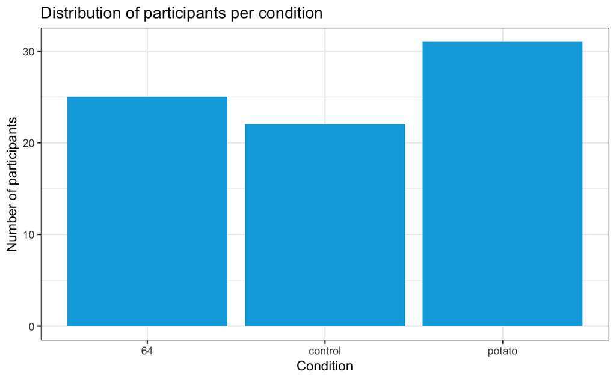

```r
## Plotting the number of participants per condition:
ggplot(tbl_org, aes(x = cond, y = n)) +
  geom_bar(stat = "identity", fill = seeblau) +
  labs(title = "Distribution of participants per condition",
       x = "Condition", y = "Number of participants") +
  theme_bw()
```

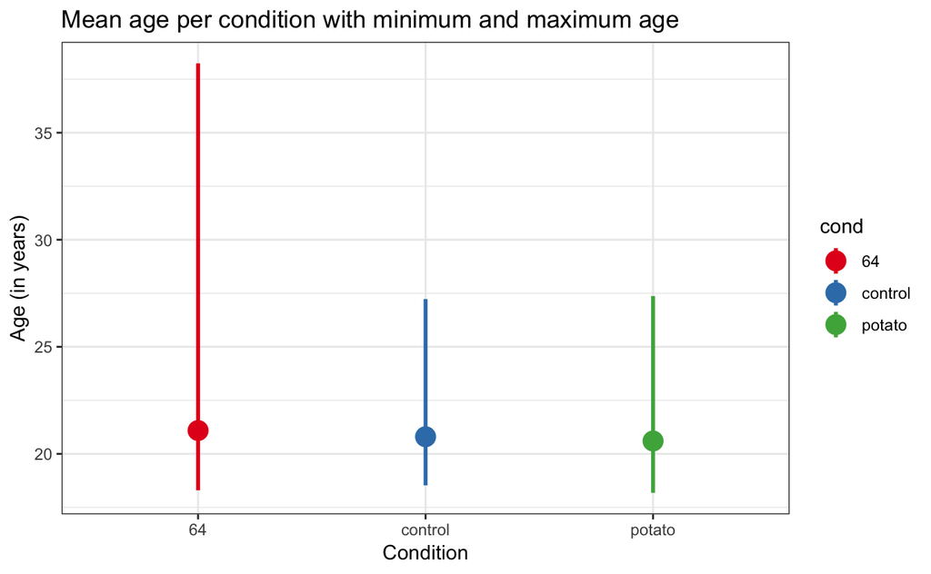

```r
## Plotting mean age per condition with the minimum and the maximum age:
ggplot(tbl_org, aes(x = cond, y = mean_age, color = cond)) +
  geom_pointrange(aes(ymin = youngest, ymax = oldest), size = 1, shape = 19) +
  labs(title = "Mean age per condition with minimum and maximum age",
       x = "Condition", y = "Age (in years)") +
  scale_color_brewer(palette = "Set1") +
  theme_bw()
```

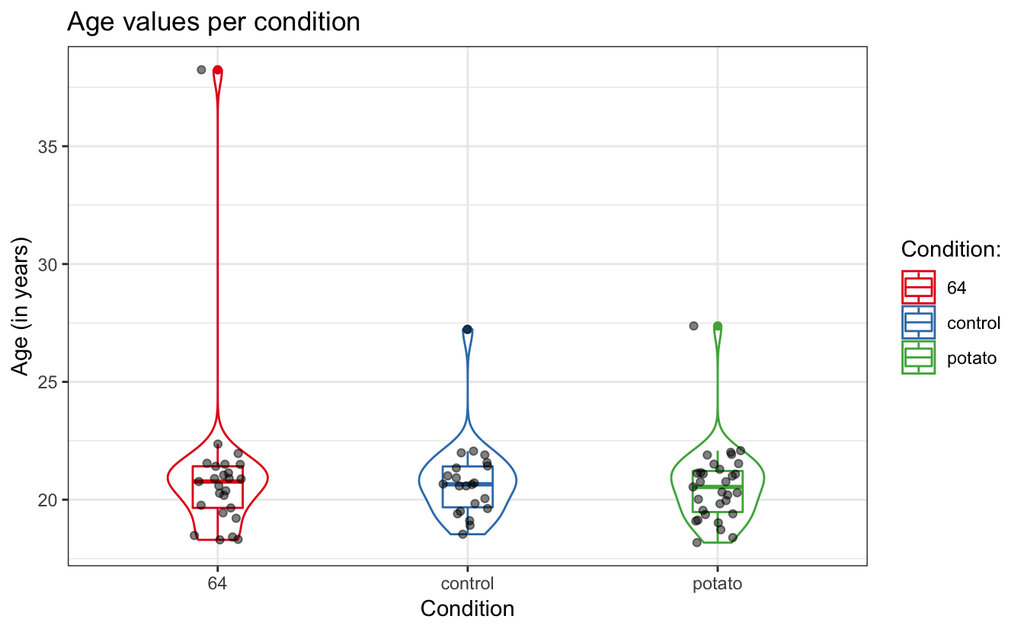

```r
## Compare with a plot from raw data: -------
# falsePosPsy_all

ggplot(falsePosPsy_all, aes(x = cond, y = aged365, color = cond)) +
  geom_violin(width = .40) +
  geom_boxplot(width = .20) +
  geom_jitter(width = .10, color = "black", alpha = 1/2) +
  labs(title = "Age values per condition",
       x = "Condition", y = "Age (in years)",
       color = "Condition:") +
  scale_color_brewer(palette = "Set1") +
  theme_bw()
```

# More on tibbles

For more details on tibbles,

- study the `vignette("tibble")` and the documentation for `?tibble`;
- study https://tibble.tidyverse.org/ and its examples;
- read [Chapter 10: Tibbles](http://r4ds.had.co.nz/tibbles.html) and complete its exercises.

See the R package [Datapasta](https://CRAN.R-project.org/package=datapasta) and its [vignette](https://cran.r-project.org/web/packages/datapasta/vignettes/how-to-datapasta.html) for a clipboard-based solution for cut-and-pasting data into [RStudio](https://www.rstudio.com/).

# Conclusion

All [ds4psy](http://rpository.com/ds4psy/) essentials:

| Nr. | Topic |
| --- | --- |
| 0. | [Syllabus](http://rpository.com/ds4psy/) |
| 1. | [Basic R concepts and commands](http://rpository.com/ds4psy/essentials/basics.html) |
| 2. | [Visualizing data](http://rpository.com/ds4psy/essentials/visualize.html) |
| 3. | [Transforming data](http://rpository.com/ds4psy/essentials/transform.html) |
| 4. | [Exploring data (EDA)](http://rpository.com/ds4psy/essentials/explore.html) |
| 5. | **Tibbles** [*](http://rpository.com/ds4psy/essentials/tibbles.html) |
| 6. | [Importing data](http://rpository.com/ds4psy/essentials/import.html) |
| 7. | [Tidying data](http://rpository.com/ds4psy/essentials/tidy.html) |
| 8. | [Joining data](http://rpository.com/ds4psy/essentials/join.html) |
| 9. | [Functions](http://rpository.com/ds4psy/essentials/function.html) |
| 10. | [Iteration](http://rpository.com/ds4psy/essentials/iteration.html) |
| +. | [Datasets](http://rpository.com/ds4psy/essentials/datasets.html) |

[Last update on 2019-05-28 10:52:38 by [hn](http://neth.de/).]